# Generated Recruitment Parameters

```r
source("./Source/prfit.R")
```

## Pre-Generate

To pre-generate recruitment parameters for a model run, we must

1. define the within year natural mortality structure
2. choose the quantile function that defines the distribution of the recruits, and
3. provide the mean and variance of the proportion of recruits seen in the surveys, and the number of surveys conducted
4. provide approximate estimate of natural mortality `M` and recruitment coefficient of variation `CV`
5. set the number of parameter sets to generate

```r
suppressPackageStartupMessages(library(dplyr))
suppressPackageStartupMessages(library(ggplot2))
suppressPackageStartupMessages(library(Grym))
suppressPackageStartupMessages(library(furrr))
set.seed(31)
```

### Model Setup

We must require the vector `Msf` that defines the total mortality within a year. To generate this we need to read in the setup parameters from the 1_Setup file.

```r
pars<-readRDS("../2_Parameters/Setup_pars_48.1_Base_case.rds")
```

Seven age classes, daily time steps - we start modelling from age 1.

```r
Days <- seq(0,1,length=pars$nsteps+1)
h <- 1/pars$nsteps
ages <- outer(Days,pars$Ages,FUN="+")
head(ages)
```

```
##          [,1]     [,2]     [,3]     [,4]     [,5]     [,6]     [,7]
## [1,] 1.000000 2.000000 3.000000 4.000000 5.000000 6.000000 7.000000
## [2,] 1.002740 2.002740 3.002740 4.002740 5.002740 6.002740 7.002740
## [3,] 1.005479 2.005479 3.005479 4.005479 5.005479 6.005479 7.005479
## [4,] 1.008219 2.008219 3.008219 4.008219 5.008219 6.008219 7.008219
## [5,] 1.010959 2.010959 3.010959 4.010959 5.010959 6.010959 7.010959
## [6,] 1.013699 2.013699 3.013699 4.013699 5.013699 6.013699 7.013699
```

Define the within year pattern of natural mortality

```r
ms <- matrix(1,pars$nsteps+1,length(pars$Ages))
Ms <- ctrapz(ms,h)
Msf <- final(Ms)
Msf
```

```
## [1] 1 1 1 1 1 1 1
```

### Distribution

Select the quantile function

```r
qdist <- qInverseBeta
recdist <- recInverseBeta
```

### Survey

Double check the survey results

```r
pars$R.mean
```

```
## [1] 0.557
```

```r
pars$R.sd
```

```
## [1] 0.126
```

```r
pars$R.var
```

```
## [1] 0.015876
```

```r
pars$R.class
```

```
## [1] 2
```

```r
pars$R.nsurveys
```

```
## [1] 17
```

### Approximate

Best guess estimates of the natural mortality `M` and recruitment coefficient of variation `CV`. The better these guesses, the faster the process will be

```r
M <- 0.5
CV <- 0.6
```

### Generate

```r
func <- function(x){prFit(qdist,Msf,pars$R.mean,pars$R.var, pars$R.nsurveys,M,CV,pars$R.class)}

plan(multiprocess, workers= availableCores()-2)
recs<- furrr::future_map_dfr(1:pars$Iterations, func,
                              .options = furrr_options(seed = TRUE),.progress=F )
plan(sequential)


colMeans(recs)
```

```
##         M        CV       mnQ       vrQ
## 0.8544540 0.5257242 1.3668376 0.6433124
```

Compare the estimated natural mortality and recruitment CVs to the actual values

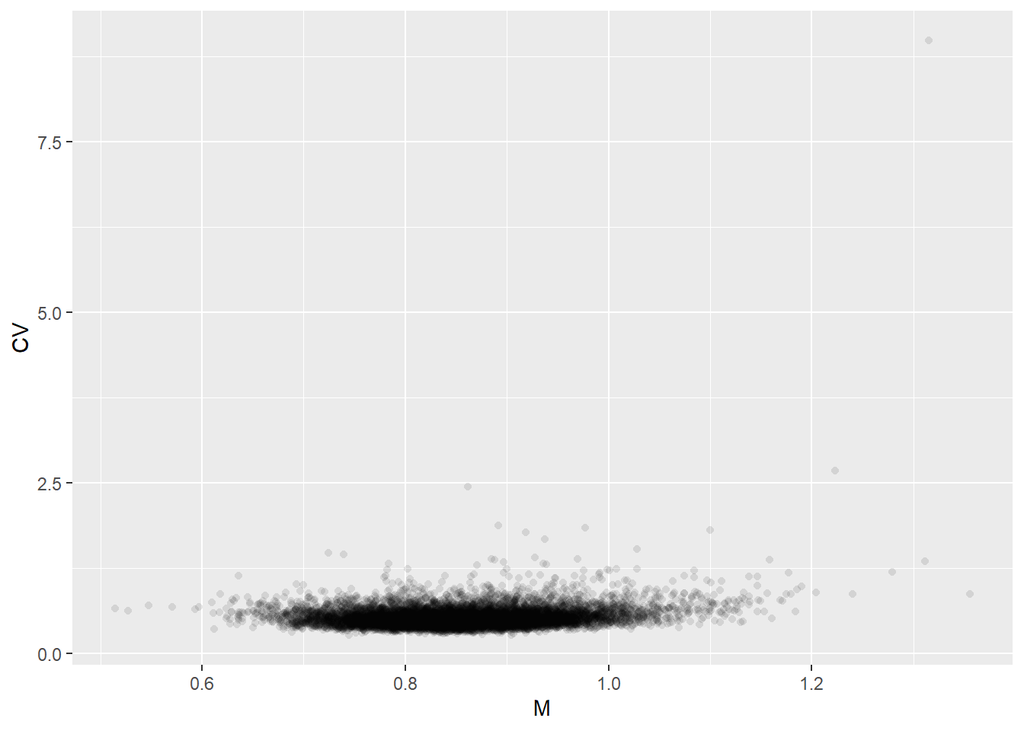

```r
ggplot(recs,aes(x=M,y=CV))+
  geom_point(shape=16,alpha=0.1)
```

Write the generated parameters to a file.

```r
saveRDS(list(R.mean=pars$R.mean,
             R.sd=pars$R.sd,
             R.class=pars$R.class,
             R.nsurveys=pars$R.nsurveys,
             qdist=qdist,
             recdist=recdist,
             pars=recs,
             Ages=pars$Ages,
             nsteps=pars$nsteps),
        file=paste0("../2_Parameters/Rec_pars_",pars$Area,"_",pars$R.mean,"_",pars$R.sd,".rds"))
```

### Check

Simulate recruitment data for a range of natural mortalities and recruitment CVs

```r
d <- recs %>%
  rowwise() %>%
  summarize(as.data.frame(t(prSim(qdist,Msf,n=pars$R.nsurveys,M,CV,r=pars$R.class))),.groups="drop") %>%
  as.data.frame()
```

Plot and compare to target values

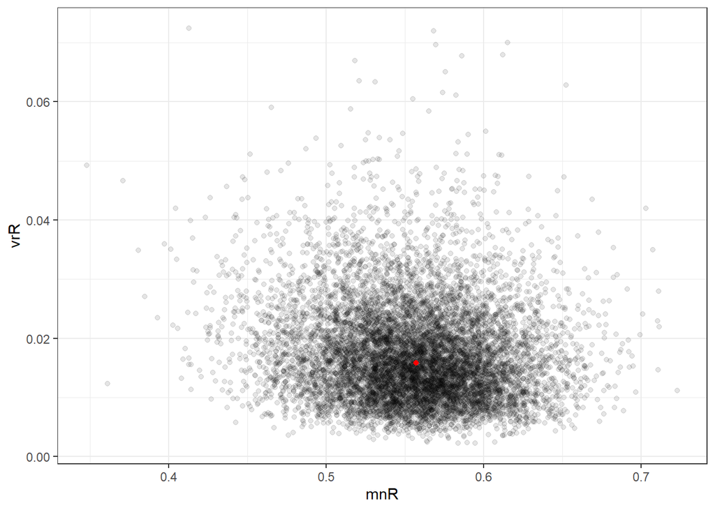

```r
ggplot(d,aes(x=mnR,y=vrR))+
  geom_point(alpha=0.1)+
  geom_point(aes(x=pars$R.mean,y=pars$R.sd^2),col="red")+
  theme_bw()
```